# Taxonomy vs. Popularity in the birds of New Zealand

2019-11-24

## Tidy tuesday looking at association between phylogeny and popularity

The [Tidy Tuesday dataset](https://github.com/rfordatascience/tidytuesday/tree/master/data/2019/2019-11-19) this week is on New Zealand’s “Bird of the Year 2019” so I thought it might be fun to look at how the taxonomy of the birds of NZ correlates with their popularity.

The packages we’ll be using this week in addition to the core tidyverse packages are `wikitaxa` to help convert common names to scientific names, `treeio` to read the phylogenetic tree into R, `ggtree` to visualize the phylogeny, and `patchwork` to combine the tree with so let’s load those and get started.

```r
library(tidyverse)
library(wikitaxa)
library(treeio)
library(ggtree)
library(patchwork)
```

We can also grab the data from the Tidy Tuesday repo

```r
nz_bird <- readr::read_csv("https://raw.githubusercontent.com/rfordatascience/tidytuesday/master/data/2019/2019-11-19/nz_bird.csv")

nz_bird
```

```
## # A tibble: 217,300 x 4
##    date        hour vote_rank bird_breed
##    <date>     <dbl> <chr>     <chr>
##  1 2019-10-28     8 vote_1    Gibson's Albatross
##  2 2019-10-28     8 vote_2    Tūī
##  3 2019-10-28     8 vote_3    Kākā
##  4 2019-10-28     8 vote_4    Kākāpō
##  5 2019-10-28     8 vote_5    Little Spotted Kiwi
##  6 2019-10-28     8 vote_1    Spotted Shag
##  7 2019-10-28     8 vote_2    Fantail
##  8 2019-10-28     8 vote_3    Weka
##  9 2019-10-28     8 vote_4    <NA>
## 10 2019-10-28     8 vote_5    <NA>
## # … with 217,290 more rows
```

The “Bird of the Year” voting was done in a rather complicated instant runoff system over several weeksm, so if we look at the raw data, we can see that we have dates, hours, and vote ranks because people could vote for up to 5 birds. To simplify this, we’ll just look at the total number of votes because that give’s the same results at least for the top birds that we’re focusing on.

## Extract the common names of the top 30 birds

If we look at the dataset, we can see that overall there were 85 different birds in the running for Bird of the Year.

```r
nz_bird %>%
    filter(!is.na(bird_breed)) %>%
    distinct(bird_breed) %>%
    nrow()
```

```
## [1] 85
```

For the sake of overcrowding, we’re going to focus on top 30 in terms of total votes

```r
top_birds <- nz_bird %>%
    filter(!is.na(vote_rank) & !is.na(bird_breed)) %>%
    count(bird_breed) %>%
    arrange(desc(n)) %>%
    top_n(30) %>%
    pull(bird_breed)

top_birds
```

```
##  [1] "Yellow-eyed penguin"       "Kākāpō"
##  [3] "Black Robin"               "Kākā"
##  [5] "Banded Dotterel"           "Kea"
##  [7] "Tūī"                       "Blue Duck"
##  [9] "Fantail"                   "New Zealand Falcon"
## [11] "Kererū"                    "Morepork"
## [13] "Antipodean Albatross"      "Little Penguin"
## [15] "Orange-fronted Parakeet"   "Rockhopper Penguin"
## [17] "Little Spotted Kiwi"       "Kingfisher"
## [19] "Southern Brown Kiwi"       "Fiordland Crested Penguin"
## [21] "South Island Kōkako"       "Mōhua"
## [23] "Kōkako"                    "New Zealand Dotterel"
## [25] "Rifleman"                  "Stitchbird"
## [27] "Takahē"                    "Bittern"
## [29] "Fairy Tern"                "Saddleback"
```

Unfortunately, the dataset only provides us with the common names of the birds, while any sort of taxonomic database is going to require (or be more accurate) if we can provide the scientific names.

## Use `wikitaxa` to obtain for scientific names from a bird’s common name

I initially tried to get the scientific names using the `comm2sci` function from the `taxize` package, but the results were pretty incomplete and inaccurate, so I next tried the `wikitaxa` package which provides an easy way to access the WikiSpecies API.

```r
bird_list <- top_birds %>%
    set_names() %>%
    map(wikitaxa::wt_wikispecies_search)
```

## Pull results from list

```r
query_results <- map(bird_list, ~pluck(.x, "query", "search"))
query_results[[2]] %>%
    select(title)
```

```
## # A tibble: 3 x 1
##   title
##   <chr>
## 1 Strigops habroptila
## 2 Strigops
## 3 Ngaheremyia fuscipennis
```

3 of the 30 elements are null in list. Banded Dotterel, Southern Brown Kiwi, and Fiordland Crested Penguin Charadrius bicinctus Apteryx australis Eudyptes pachyrhynchus

```r
missing_birds <- keep(query_results, is.null) %>% names()

# wiki_list <- missing_birds %>%
#     set_names() %>%
#     map(wt_wikipedia_search)
#
# wiki_query_results <- map(wiki_results, ~pluck(.x, "query", "search")) %>%
#     map_dfr(compact, .id = "common_name")
```

## Problems with taking first result

```r
top_result <- map_dfr(query_results, ~head(.x, 1), .id = "common_name") %>%
    select(common_name, title, pageid, snippet)
```

## Manually fix a few

```r
query_results_fulldf <- query_results %>%
    map_dfr(compact, .id = "common_name")

bird_names <- query_results_fulldf %>%
    filter(!title %in% c("Black robin associated gemykibivirus 1",
                         "Steven Chew Kea Foo",
                         "Thyrocopa kea",
                         "Domene tui",
                         "Avian avulavirus 10",
                         "Haplomitrium ovalifolium",
                         "Cerylinae",
                         "Sibine stimulea",
                         "Homaloptera parclitella",
                         "Mohoua")) %>%
    distinct(common_name, .keep_all = TRUE) %>%
    select(common_name, latin_name = title) %>%
    mutate(latin_name = str_replace_all(latin_name,
                                        c("Gemykibivirus" ="Petroica traversi",
                                          "Eudyptula" = "Eudyptula minor",
                                          "Acanthisitta" = "Acanthisitta chloris",
                                          "Ixobrychus" = "Ixobrychus sturmii"
                                          )))
```

```r
plot_set <- bird_names %>%
    pull(latin_name)
```

Manually add scientific name for missing birds because it is only 3. If part of a bigger project, would look into trying to webscrape latin names from wikipedia.

```r
missing_bird_names <- tibble(
    common_name = missing_birds,
    latin_name = c("Charadrius bicinctus", "Apteryx australis", "Eudyptes pachyrhynchus")
)

bird_names_complete <- bind_rows(bird_names, missing_bird_names)

plot_set <- bird_names_complete %>%
    pull(latin_name)
```

## Save to file and then input to NCBI

Rather than building our own phylogeny from sequence data, we’re going to use the [NCBI Common Tree](https://www.ncbi.nlm.nih.gov/taxonomy) to infer our phylogeny.

```r
write_lines(plot_set, "sci_names.txt")
```

https://www.ncbi.nlm.nih.gov/Taxonomy/CommonTree/wwwcmt.cgi

One species not found

## Import tree back into R

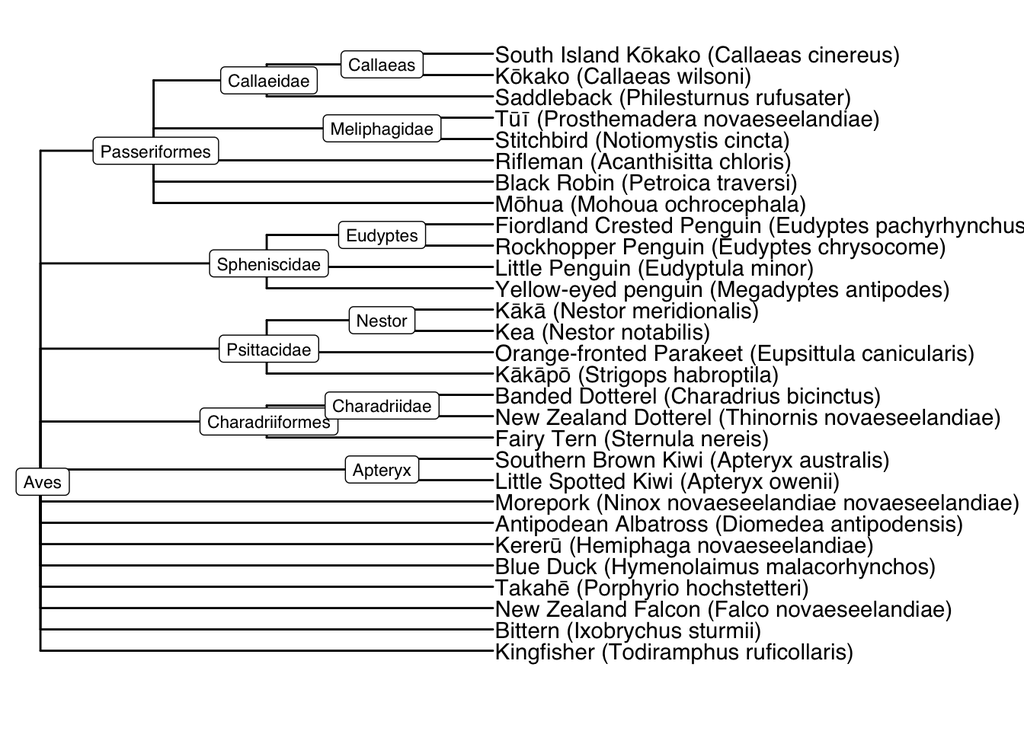

```r
raw_tree <- treeio::read.tree("~/Downloads/phyliptree_fix.phy") %>%
    as_tibble() %>%
    mutate(label = str_replace_all(label, "_", " ")) %>%
    left_join(bird_names_complete, by = c("label" = "latin_name")) %>%
    mutate(label = if_else(!is.na(common_name), glue::glue("{common_name} ({label})"),
                           label))

tree <- as.phylo(raw_tree)

ggtree(tree, branch.length = "none") +
    geom_nodelab(geom = "label", size = 3) +
    geom_tiplab() +
    coord_cartesian(clip = 'off') +
    ylim(0.5, 29.5) +
    theme_tree2() +
    theme(plot.margin=margin(6, 250, 6, 6),
          axis.line.x = element_line(color = "transparent"),
          axis.ticks.x = element_line(color = "transparent"),
          axis.text = element_text(color = "transparent"))
```

## Now add vote data for each bird

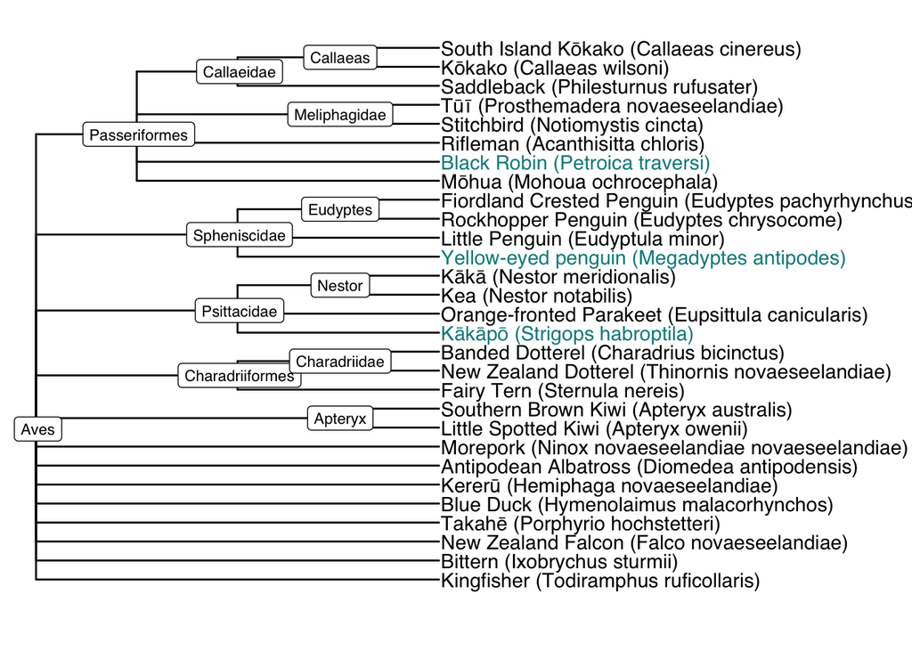

```r
bar_df <- nz_bird %>%
    filter(!is.na(vote_rank) & !is.na(bird_breed)) %>%
    count(bird_breed) %>%
    arrange(desc(n)) %>%
    top_n(30) %>%
    left_join(bird_names_complete, by = c("bird_breed" = "common_name")) %>%
    mutate(label = glue::glue("{bird_breed} ({latin_name})")) %>%
    select(label, n)

highlight <- bar_df %>%
    head(3) %>%
    pull(label)

colors <- c("black", "darkcyan")

p <- ggtree(tree, branch.length = "none") +
    geom_nodelab(geom = "label", size = 3) +
    geom_tiplab(aes(color = label %in% highlight), show.legend = FALSE) +
    scale_color_manual(values = colors) +
    coord_cartesian(clip = 'off') +
    ylim(0.5, 29.5) +
    theme_tree2() +
    theme(plot.margin=margin(6, 250, 6, 6),
          axis.line.x = element_line(color = "transparent"),
          axis.ticks.x = element_line(color = "transparent"),
          axis.text = element_text(color = "transparent"))
p
```

```r
# ggcol_inset <- function(df) {
#   ggplot(df) +
#     aes(x = 0, y = n) +
#     geom_col() +
#     geom_text(x = 0, y = n+5, label = label,hjust = -0.2) +
#     ylim(c(0, ymax + 1)) +
#     coord_flip() +
#     theme_inset()
# }

# p +  geom_facet(panel = "# Votes", data = bar_df, geom = ggstance::geom_barh,
#                 aes(x = n),
#                 stat = "identity", width = .6) +
```

## Make Bar plot

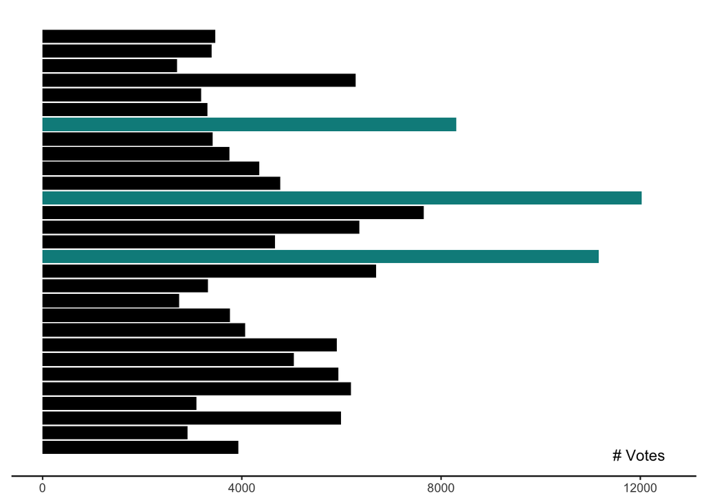

```r
p1 <- p %>%
    filter(isTip) %>%
    select(label, y) %>%
    left_join(bar_df) %>%
    mutate(highlight = if_else(n > 8000, "yes", "no")) %>%
    ggplot(aes(y, n, fill = highlight)) +
    geom_col(show.legend = FALSE) +
    scale_fill_manual(values = colors) +
    coord_flip() +
    annotate("text", x = 0.5, y = 12500, label = "# Votes", hjust = 1) +
    xlim(0.5, 29.5) +
    theme_tree2()
p1
```

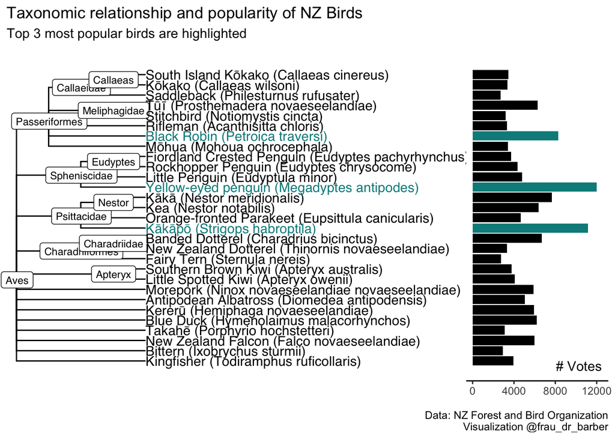

```r
p + p1 + plot_annotation(
    title = "Taxonomic relationship and popularity of NZ Birds",
    subtitle = "Top 3 most popular birds are highlighted",
    caption = "Data: NZ Forest and Bird Organization\n Visualization @frau_dr_barber"
    )
```

```r
ggsave("plot.png", width = 8, height = 6)
```